# Lab 8: Bagging, Random Forest and Boosting

Yangyi Lu

2/28/2020

In this lab, we use spam email dataset to illustrate three classification methods: bagging, random forest and boosting. Spam email dataset is accessible at https://archive.ics.uci.edu/ml/datasets/spambase. There are 4601 rows, each row is a vector of length 58, containing information about words in an email. There are 58 columns, 48 of them represent word frequencies, 6 of them represent some character frequencies, 3 of them represent capital letter information and the last column contains the true class labels: 0 for non-spam, 1 for spam.

## Load the Spam Dataset

```r
set.seed(1)
dat = read.csv("spambase.data",header = F)

# loading column names
names = read.table("names.txt")
colnames(dat) = names[,1]

# convert class label column to factor variable
dat$spam = factor(dat$spam)
levels(dat$spam) = c("Non-Spam", "Spam")

# spliting training and testing set
n = nrow(dat)
train_id = sample(n,size = floor(n*0.7))
train = dat[train_id,]
test = dat[-train_id,]
```

## Tree Model Revisit

The spam and non-spam individuals in training dataset are balanced enough.

```r
table(train$spam)
```

```
##
## Non-Spam     Spam
##     1930     1290
```

```r
library(rpart)
library(rpart.plot)
tree_entropy = rpart(spam ~ ., data = train, parms = list(split = "gini"),
                     method = "class", cp = 0.012)
```

We next use the fitted `tree_entropy` model to calculate the training and testing error.

```r
# training error
train_pred = predict(tree_entropy,train,type = "class")
table(train_pred,train$spam)
```

```
##
## train_pred Non-Spam Spam
##   Non-Spam     1834  231
##   Spam           96 1059
```

```r
train_err = mean(train_pred!=train$spam)
train_err
```

```
## [1] 0.1015528
```

```r
# testing error
test_pred = predict(tree_entropy,test,type = "class")
table(test_pred,test$spam)
```

```
##
## test_pred  Non-Spam Spam
##   Non-Spam      823  107
##   Spam           35  416
```

```r
test_err = mean(test_pred!=test$spam)
test_err
```

```
## [1] 0.102824
```

## Bagging

Here we apply bagging to spam email data, using `randomForest` package. The exact results obtained in this section may depend on the version of R and the version of the `randomForest` package installed on your computer.

Recall that bagging is simply a special case of a random forest with $m=p$, where $m$ is the number of feature being sampled to build trees and $p$ is the number of all features. Therefore, the `randomForest()` function can be used to perform both random forests and bagging. We will perform bagging first as follows:

```r
library(randomForest)
set.seed(1)
bag_spam = randomForest(spam ~ ., data = train, mtry = ncol(train)-1,
                        importance = TRUE, ntree = 500)
bag_spam
```

```
##
## Call:
##  randomForest(formula = spam ~ ., data = train, mtry = ncol(train) -      1, importance = TRUE, ntree = 500)
##                Type of random forest: classification
##                      Number of trees: 500
## No. of variables tried at each split: 57
##
##         OOB estimate of  error rate: 5.62%
## Confusion matrix:
##          Non-Spam Spam class.error
## Non-Spam     1855   75  0.03886010
## Spam          106 1184  0.08217054
```

How well does this bagging model perform on test set?

```r
bag_test_pred = predict(bag_spam, newdata = test)
table(bag_test_pred, test$spam)
```

```
##
## bag_test_pred Non-Spam Spam
##      Non-Spam      830   47
##      Spam           28  476
```

```r
bag_test_err = mean(bag_test_pred!=test$spam)
bag_test_err
```

```
## [1] 0.05430847
```

Above result greatly improves the one using single tree based model.

## Random Forest

Random forest procedures are identical to bagging except that we only use a fraction of features to grow trees. By default, `randomForest()` uses $\sqrt{p}$ variables when building classfication trees. We will try multiple `mtry` here.

```r
set.seed(1)
rf_spam = randomForest(spam ~ ., data = train, mtry = floor(sqrt(57)),
                       importance = TRUE)
rf_spam
```

```
##
## Call:
##  randomForest(formula = spam ~ ., data = train, mtry = floor(sqrt(57)),      importance = TRUE)
##                Type of random forest: classification
##                      Number of trees: 500
## No. of variables tried at each split: 7
##
##         OOB estimate of  error rate: 4.94%
## Confusion matrix:
##          Non-Spam Spam class.error
## Non-Spam     1868   62  0.03212435
## Spam           97 1193  0.07519380
```

```r
rf_test_pred = predict(rf_spam, newdata = test)
table(rf_test_pred, test$spam)
```

```
##
## rf_test_pred Non-Spam Spam
##     Non-Spam      832   38
##     Spam           26  485
```

```r
rf_test_err = mean(rf_test_pred!=test$spam)
rf_test_err
```

```
## [1] 0.04634323
```

Above result improves the bagging model.

Next, we use the `importance()` function to view the importance of each variable.

```r
importance(rf_spam)[1:15,]
```

```
##                      Non-Spam       Spam MeanDecreaseAccuracy MeanDecreaseGini
## word_freq_make       4.441853  7.1981878             7.556960         5.802333
## word_freq_address    8.093847  6.9480695             9.661915         8.493919
## word_freq_all        5.326037 14.2299399            14.092138        16.232818
## word_freq_3d         6.063038  0.2416555             5.041660         1.551283
## word_freq_our       20.618147 21.3184410            26.099248        45.451885
## word_freq_over       9.826634 11.8148219            14.357199        11.576952
## word_freq_remove    34.746000 30.3198448            37.086419       118.986395
## word_freq_internet  14.103821  9.4754999            15.443737        14.531215
## word_freq_order      9.509268  7.8660568            10.943360         6.906545
## word_freq_mail      10.863822  9.6671171            14.256133        11.716167
## word_freq_receive   13.984815  5.3951318            13.844145        14.420415
## word_freq_will       6.691211 16.1953189            16.808404        17.287704
## word_freq_people     3.524059  7.0405492             6.923985         6.463639
## word_freq_report     5.988369  9.1024475             9.240906         4.019387
## word_freq_addresses  6.774136  3.6386341             7.013253         2.282049
```

Two measures of variable importance are reported. The former is based upon the mean decrease of accuracy in predictions on the out of bag samples when a given variable is excluded from the model. The latter is a measure of the total decrease in node impurity that results from splits over that variable, averaged over all trees.

Plots of these importance measures can be produced using the `varImpPlot()` function.

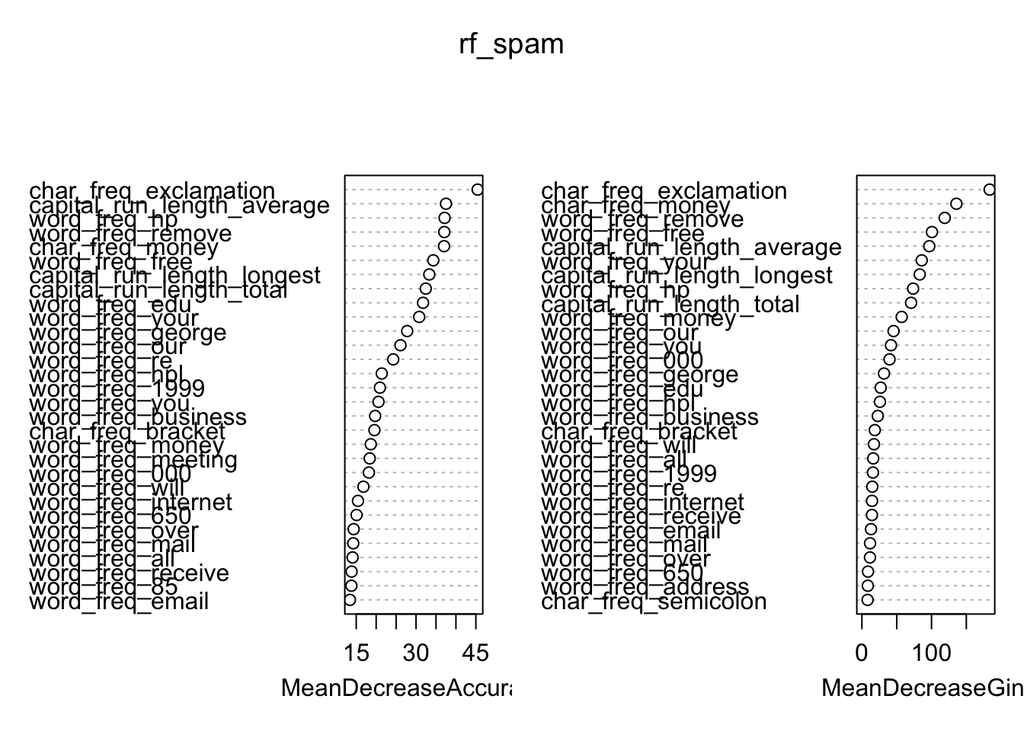

```r
varImpPlot(rf_spam)
```

Now let’s try using a smaller value $5$ for `mtry`.

```r
set.seed(1)
rf_spam_1 = randomForest(spam ~ ., data = train, mtry = 5, importance = TRUE)
rf_spam_1
```

```
##
## Call:
##  randomForest(formula = spam ~ ., data = train, mtry = 5, importance = TRUE)
##                Type of random forest: classification
##                      Number of trees: 500
## No. of variables tried at each split: 5
##
##         OOB estimate of  error rate: 4.91%
## Confusion matrix:
##          Non-Spam Spam class.error
## Non-Spam     1868   62  0.03212435
## Spam           96 1194  0.07441860
```

How well does this random forest with `mtry` around $5$ model perform on test set?

```r
rf_test_pred_1 = predict(rf_spam_1, newdata = test)
table(rf_test_pred_1, test$spam)
```

```
##
## rf_test_pred_1 Non-Spam Spam
##       Non-Spam      836   41
##       Spam           22  482
```

```r
rf_test_err_1 = mean(rf_test_pred_1!=test$spam)
rf_test_err_1
```

```
## [1] 0.04561912
```

## Boosting

Here we use `gbm` package, specifically the `gbm()` function within it, to fit boosting model for the spam email dataset.

### Adaboost

Adaboost builds an additive model by stagewise fitting using the exponential loss function. Here we set `distribution="adaboost"` in `gbm()`. By default, the `shrinkage` parameter $\mu$ is set to $0.1$, which controls the speed of boosting.
$$f(x) = \sum_{m=1}^M\mu\alpha_mT_m(x)$$
We will try different shrinkage parameters to see how this affects the prediction performance.

In `gbm`, we need to ensure that the outcome variable is represented by $0$ or $1$. So we first convert “Spam” and “Non-spam” to $1$ and $0$.

#### Depth 3, tree 5000: early stopping can avoid overfitting

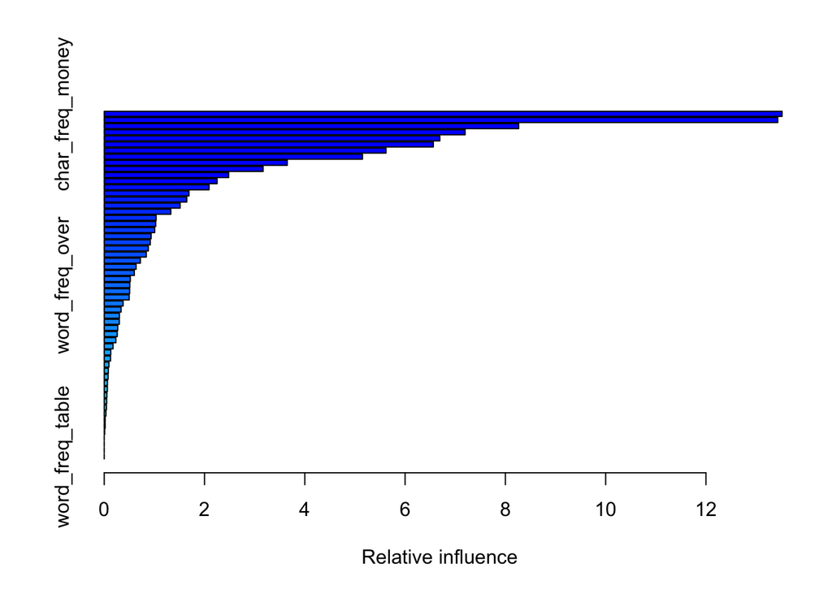

```
##                                                   var      rel.inf
## char_freq_money                       char_freq_money 13.517934533
## char_freq_exclamation           char_freq_exclamation 13.431917120
## word_freq_remove                     word_freq_remove  8.265401304
## capital_run_length_average capital_run_length_average  7.196960835
## word_freq_free                         word_freq_free  6.692772239
## word_freq_hp                             word_freq_hp  6.562489470
## capital_run_length_total     capital_run_length_total  5.619536767
## word_freq_your                         word_freq_your  5.150269264
## word_freq_you                           word_freq_you  3.650186147
## capital_run_length_longest capital_run_length_longest  3.168072962
## word_freq_edu                           word_freq_edu  2.481699097
## word_freq_george                     word_freq_george  2.250992030
## word_freq_people                     word_freq_people  2.090827055
## char_freq_bracket                   char_freq_bracket  1.690523649
## word_freq_our                           word_freq_our  1.645918607
## word_freq_will                         word_freq_will  1.513611224
## word_freq_re                             word_freq_re  1.327497029
## word_freq_receive                   word_freq_receive  1.035446928
## char_freq_semicolon               char_freq_semicolon  1.026638056
## word_freq_650                           word_freq_650  1.006849200
## word_freq_money                       word_freq_money  0.935329758
## word_freq_mail                         word_freq_mail  0.917925462
## word_freq_report                     word_freq_report  0.878917243
## word_freq_email                       word_freq_email  0.838827852
## word_freq_business                 word_freq_business  0.720200172
## word_freq_meeting                   word_freq_meeting  0.635297571
## word_freq_internet                 word_freq_internet  0.600334120
## word_freq_000                           word_freq_000  0.520007492
## word_freq_over                         word_freq_over  0.509625956
## word_freq_technology             word_freq_technology  0.506744887
## word_freq_1999                         word_freq_1999  0.497789149
## word_freq_original                 word_freq_original  0.375927100
## word_freq_order                       word_freq_order  0.336042496
## word_freq_all                           word_freq_all  0.302421473
## word_freq_data                         word_freq_data  0.300290355
## word_freq_hpl                           word_freq_hpl  0.269877923
## word_freq_3d                             word_freq_3d  0.259651453
## word_freq_credit                     word_freq_credit  0.232118029
## word_freq_project                   word_freq_project  0.175615100
## word_freq_address                   word_freq_address  0.130814858
## word_freq_make                         word_freq_make  0.125355831
## char_freq_hash                         char_freq_hash  0.093479984
## word_freq_parts                       word_freq_parts  0.082520290
## word_freq_conference             word_freq_conference  0.077235085
## word_freq_font                         word_freq_font  0.064207224
## char_freq_bracket2                 char_freq_bracket2  0.062740511
## word_freq_labs                         word_freq_labs  0.052386638
## word_freq_direct                     word_freq_direct  0.049221665
## word_freq_85                             word_freq_85  0.043238275
## word_freq_pm                             word_freq_pm  0.034413804
## word_freq_addresses               word_freq_addresses  0.018516495
## word_freq_lab                           word_freq_lab  0.018240023
## word_freq_cs                             word_freq_cs  0.009142208
## word_freq_telnet                     word_freq_telnet  0.000000000
## word_freq_857                           word_freq_857  0.000000000
## word_freq_415                           word_freq_415  0.000000000
## word_freq_table                       word_freq_table  0.000000000
```

```r
library(gbm)
set.seed(1)
train$spam = ifelse(train$spam=="Spam",1,0)
test$spam = ifelse(test$spam=="Spam",1,0)
ada_spam = gbm(spam~., data = train, distribution = "adaboost", n.trees = 5000,
               interaction.depth = 3)
summary(ada_spam)
```

First, let’s calculate the testing error of the additive model using all 5000 trees.

```r
ada_pred_response = predict(ada_spam, newdata = test, n.trees = 5000,
                            type = "response")
ada_pred = ifelse(ada_pred_response>0.5,1,0)
table(ada_pred,test$spam)
```

```
##
## ada_pred   0   1
##        0 823  34
##        1  35 489
```

```r
ada_err = mean(ada_pred!=test$spam)
ada_err
```

```
## [1] 0.04996379
```

Now let’s only use the first 1000 fitted trees.

```r
ada_pred_response_ES = predict(ada_spam, newdata = test, n.trees = 1000,
                               type = "response")
ada_pred_ES = ifelse(ada_pred_response_ES>0.5,1,0)
table(ada_pred_ES,test$spam)
```

```
##
## ada_pred_ES   0   1
##           0 827  34
##           1  31 489
```

```r
ada_err_ES = mean(ada_pred_ES!=test$spam)
ada_err_ES
```

```
## [1] 0.04706734
```

Shrinkage parameter controls the speed of model updating, let’s now try a small shrinkage parameter, but keep the number of trees unchanged.

```r
set.seed(1)
ada_spam_1 = gbm(spam~., data = train, distribution = "adaboost",
                 n.trees = 1000, interaction.depth = 3, shrinkage = 0.01)
ada_pred_response_1 = predict(ada_spam_1, newdata = test, n.trees = 1000,
                              type = "response")
ada_pred_1 = ifelse(ada_pred_response_1>0.5,1,0)
table(ada_pred_1,test$spam)
```

```
##
## ada_pred_1   0   1
##          0 826  52
##          1  32 471
```

```r
ada_err_1 = mean(ada_pred_1!=test$spam)
ada_err_1
```

```
## [1] 0.06082549
```

The above results show that only changing the shrinkage parameter to be smaller hurts the prediction performance. The reason is we keep the number of updates unchanged, but reducing the amount of update at every iteration. So when we finish fitting all the 1000 trees, the model may still not converge.

#### Use more weak predictors (number of trees) for small shrinkage parameter $0.01$

Since our shrinkage is $0.01$ here, comparing to the first adaboost model which uses $0.1$, the udpating amount at every iteration shrinkages by 10 times. Thus, we will use $10000$ trees instead of only $1000$ to keep the same amount of total updating.

```r
set.seed(1)
ada_spam_2 = gbm(spam~., data = train, distribution = "adaboost",
                 n.trees = 10000, interaction.depth = 3, shrinkage = 0.01)
ada_pred_response_2 = predict(ada_spam_2, newdata = test, n.trees = 10000,
                              type = "response")
ada_pred_2 = ifelse(ada_pred_response_2>0.5,1,0)
table(ada_pred_2,test$spam)
```

```
##
## ada_pred_2   0   1
##          0 827  31
##          1  31 492
```

```r
ada_err_2 = mean(ada_pred_2!=test$spam)
ada_err_2
```

```
## [1] 0.044895
```

We observe that when updating the model slower, which means using smaller shrinkage parameter, increasing the number of trees can improve the prediction performance.

### Boosting with logistic regression loss

Here we use `gbm()` function with `distribution = "bernoulli"`.

```r
set.seed(1)
logit_spam = gbm(spam~., data = train, distribution = "bernoulli",
                 n.trees = 1000, interaction.depth = 3, shrinkage = 0.1)
logit_pred_response = predict(logit_spam, newdata = test, n.trees = 1000,
                              type = "response")
logit_pred = ifelse(logit_pred_response>0.5,1,0)
table(logit_pred,test$spam)
```

```
##
## logit_pred   0   1
##          0 825  33
##          1  33 490
```

```r
logit_err = mean(logit_pred!=test$spam)
logit_err
```

```
## [1] 0.04779146
```

The prediction performance is similar to adaboost. We summarize some representative model’s testing error results in below:

1. tree: 0.1028
2. bagging: 0.0543
3. best rf: 0.0456
4. best adaboost: 0.0449
5. boosting with logit loss: 0.0478